# Predictions

Jeff Walker

1/30/2015

# 1 Get Data

```
## Source: local data frame [6 x 7]
##
##   location_id                location_name featureid latitude longitude
## 1        1473                       S-1019        NA 46.74704 -67.97143
## 2        1474                       S-1016        NA 46.67041 -68.01328
## 3        1428                 Finney Brook    833458 42.45973 -72.69103
## 4        1427                      9999999    805717 43.18900 -71.47800
## 5        1454           Avery Brook, upper    833141 42.46538 -72.71110
## 6        1452 Obear Brook, below Webber Rd    834183 42.43242 -72.67777
## Variables not shown: agency_name (chr), site (chr)
```

Select a location for making predictions.

```
## [1] 830189
```

Retrieve daymet data for select catchment.

```
##    featureid           date                 tmax             tmin
##  Min.   :830189   Min.   :1980-01-01   Min.   :-19.25   Min.   :-32.000
##  1st Qu.:830189   1st Qu.:1988-07-01   1st Qu.:  5.00   1st Qu.: -4.750
##  Median :830189   Median :1996-12-31   Median : 14.50   Median :  2.000
##  Mean   :830189   Mean   :1996-12-31   Mean   : 13.82   Mean   :  1.978
##  3rd Qu.:830189   3rd Qu.:2005-07-01   3rd Qu.: 23.25   3rd Qu.: 10.250
##  Max.   :830189   Max.   :2013-12-31   Max.   : 35.25   Max.   : 21.750
##       prcp              dayl            srad             vp
##  Min.   :  0.000   Min.   :32141   Min.   : 35.2   Min.   :  40.0
##  1st Qu.:  0.000   1st Qu.:35597   1st Qu.:216.0   1st Qu.: 440.0
##  Median :  0.000   Median :43200   Median :315.2   Median : 720.0
##  Mean   :  3.472   Mean   :43200   Mean   :321.0   Mean   : 857.5
##  3rd Qu.:  3.000   3rd Qu.:50803   3rd Qu.:427.2   3rd Qu.:1260.0
##  Max.   :132.500   Max.   :54259   Max.   :697.6   Max.   :2600.0
##       swe             site              airTemp
##  Min.   :  0.00   Length:12410       Min.   :-23.250
##  1st Qu.:  0.00   Class :character   1st Qu.:  0.125
##  Median :  0.00   Mode  :character   Median :  8.250
##  Mean   : 26.96                      Mean   :  7.900
##  3rd Qu.: 40.00                      3rd Qu.: 16.625
##  Max.   :248.00                      Max.   : 27.875
```

Get the covariates for the selected catchment

```
## Observations: 1
## Variables:
## $ featureid    (int) 830189
## $ zone         (chr) "upstream"
## $ AreaSqKM     (dbl) 2.979
## $ agriculture  (dbl) 12.6284
## $ alloffnet    (dbl) 2.99094
## $ allonnet     (dbl) 3.89728
## $ devel_hi     (dbl) 0
## $ devel_low    (dbl) 0.543807
## $ devel_med    (dbl) 0
## $ devel_opn    (dbl) 6.19335
## $ developed    (dbl) 6.73716
## $ elev_nalcc   (dbl) 282.097
## $ forest       (dbl) 79.1238
## $ forest_decid (dbl) 16.5559
## $ forest_evgrn (dbl) 25.8912
## $ forest_mixed (dbl) 37.9758
## $ fwswetlands  (dbl) 6.67674
## $ herbaceous   (dbl) 0.21148
## $ surfcoarse   (dbl) 0
## $ water        (dbl) 0
## $ wetland      (dbl) 11.2689
```

Get spring/fall breakpoints

```
##    Spring      Fall
##  89.78214 311.69958
```

Join climate data, covariates, observed stream temperature, huc8, lat/lon, spring/fall breakpoints and add dOY. Then filter dataset to be within spring/fall breakpoints.

```
##    featureid           date                 tmax            tmin
##  Min.   :830189   Min.   :1980-03-30   Min.   :-6.75   Min.   :-12.000
##  1st Qu.:830189   1st Qu.:1988-07-09   1st Qu.:16.00   1st Qu.:  3.000
##  Median :830189   Median :1996-10-19   Median :21.50   Median :  8.500
##  Mean   :830189   Mean   :1996-12-31   Mean   :20.61   Mean   :  8.079
##  3rd Qu.:830189   3rd Qu.:2005-06-25   3rd Qu.:26.00   3rd Qu.: 13.000
##  Max.   :830189   Max.   :2013-11-07   Max.   :35.25   Max.   : 21.750
##
##       prcp              dayl            srad             vp
##  Min.   :  0.000   Min.   :35251   Min.   : 48.0   Min.   : 240
##  1st Qu.:  0.000   1st Qu.:44582   1st Qu.:278.4   1st Qu.: 760
##  Median :  0.000   Median :49421   Median :377.6   Median :1120
##  Mean   :  3.637   Mean   :48015   Mean   :366.1   Mean   :1163
##  3rd Qu.:  3.500   3rd Qu.:52877   3rd Qu.:456.0   3rd Qu.:1480
##  Max.   :132.500   Max.   :54259   Max.   :697.6   Max.   :2600
##
##       swe             site              airTemp           zone
##  Min.   :  0.00   Length:7511        Min.   :-9.375   Length:7511
##  1st Qu.:  0.00   Class :character   1st Qu.: 9.625   Class :character
##  Median :  0.00   Mode  :character   Median :15.000   Mode  :character
##  Mean   : 10.17                      Mean   :14.342
##  3rd Qu.:  0.00                      3rd Qu.:19.312
##  Max.   :224.00                      Max.   :27.875
##
##     AreaSqKM      agriculture      alloffnet        allonnet
##  Min.   :2.979   Min.   :12.63   Min.   :2.991   Min.   :3.897
##  1st Qu.:2.979   1st Qu.:12.63   1st Qu.:2.991   1st Qu.:3.897
##  Median :2.979   Median :12.63   Median :2.991   Median :3.897
##  Mean   :2.979   Mean   :12.63   Mean   :2.991   Mean   :3.897
##  3rd Qu.:2.979   3rd Qu.:12.63   3rd Qu.:2.991   3rd Qu.:3.897
##  Max.   :2.979   Max.   :12.63   Max.   :2.991   Max.   :3.897
##
##     devel_hi   devel_low        devel_med   devel_opn       developed
##  Min.   :0   Min.   :0.5438   Min.   :0   Min.   :6.193   Min.   :6.737
##  1st Qu.:0   1st Qu.:0.5438   1st Qu.:0   1st Qu.:6.193   1st Qu.:6.737
##  Median :0   Median :0.5438   Median :0   Median :6.193   Median :6.737
##  Mean   :0   Mean   :0.5438   Mean   :0   Mean   :6.193   Mean   :6.737
##  3rd Qu.:0   3rd Qu.:0.5438   3rd Qu.:0   3rd Qu.:6.193   3rd Qu.:6.737
##  Max.   :0   Max.   :0.5438   Max.   :0   Max.   :6.193   Max.   :6.737
##
```

[output cut: 25 more lines]

```
##  Min.   :-72.08   Min.   :1980   Min.   : 85.0   Length:7511
##  1st Qu.:-72.08   1st Qu.:1988   1st Qu.: 85.0   Class :character
##  Median :-72.08   Median :1996   Median : 93.5   Mode  :character
##  Mean   :-72.08   Mean   :1996   Mean   : 93.3
##  3rd Qu.:-72.08   3rd Qu.:2005   3rd Qu.:102.0
##  Max.   :-72.08   Max.   :2013   Max.   :102.0
##                                  NA's   :6882
##   finalFallBP    sourceFallBP            dOY
##  Min.   :293.0   Length:7511        Min.   : 90.0
##  1st Qu.:293.0   Class :character   1st Qu.:145.0
##  Median :308.0   Mode  :character   Median :200.0
##  Mean   :308.5                      Mean   :200.4
##  3rd Qu.:323.0                      3rd Qu.:256.0
##  Max.   :323.0                      Max.   :311.0
##  NA's   :6882
```

Rename some columns to match old variable names

Sort `fullDataSync` by site, year and dOY. Then compute lagged airTemp and prcp.

```
##    featureid           date                 tmax            tmin
##  Min.   :830189   Min.   :1980-03-30   Min.   :-6.75   Min.   :-12.000
##  1st Qu.:830189   1st Qu.:1988-07-09   1st Qu.:16.00   1st Qu.:  3.000
##  Median :830189   Median :1996-10-19   Median :21.50   Median :  8.500
##  Mean   :830189   Mean   :1996-12-31   Mean   :20.61   Mean   :  8.079
##  3rd Qu.:830189   3rd Qu.:2005-06-25   3rd Qu.:26.00   3rd Qu.: 13.000
##  Max.   :830189   Max.   :2013-11-07   Max.   :35.25   Max.   : 21.750
##
##       prcp              dayl            srad             vp
##  Min.   :  0.000   Min.   :35251   Min.   : 48.0   Min.   : 240
##  1st Qu.:  0.000   1st Qu.:44582   1st Qu.:278.4   1st Qu.: 760
##  Median :  0.000   Median :49421   Median :377.6   Median :1120
##  Mean   :  3.637   Mean   :48015   Mean   :366.1   Mean   :1163
##  3rd Qu.:  3.500   3rd Qu.:52877   3rd Qu.:456.0   3rd Qu.:1480
##  Max.   :132.500   Max.   :54259   Max.   :697.6   Max.   :2600
##
##       swe             site              airTemp           zone
##  Min.   :  0.00   Length:7511        Min.   :-9.375   Length:7511
##  1st Qu.:  0.00   Class :character   1st Qu.: 9.625   Class :character
##  Median :  0.00   Mode  :character   Median :15.000   Mode  :character
##  Mean   : 10.17                      Mean   :14.342
##  3rd Qu.:  0.00                      3rd Qu.:19.312
##  Max.   :224.00                      Max.   :27.875
##
##    TotDASqKM      agriculture      alloffnet        allonnet
##  Min.   :2.979   Min.   :12.63   Min.   :2.991   Min.   :3.897
##  1st Qu.:2.979   1st Qu.:12.63   1st Qu.:2.991   1st Qu.:3.897
##  Median :2.979   Median :12.63   Median :2.991   Median :3.897
##  Mean   :2.979   Mean   :12.63   Mean   :2.991   Mean   :3.897
##  3rd Qu.:2.979   3rd Qu.:12.63   3rd Qu.:2.991   3rd Qu.:3.897
##  Max.   :2.979   Max.   :12.63   Max.   :2.991   Max.   :3.897
##
##     devel_hi   devel_low        devel_med   devel_opn       developed
##  Min.   :0   Min.   :0.5438   Min.   :0   Min.   :6.193   Min.   :6.737
##  1st Qu.:0   1st Qu.:0.5438   1st Qu.:0   1st Qu.:6.193   1st Qu.:6.737
##  Median :0   Median :0.5438   Median :0   Median :6.193   Median :6.737
##  Mean   :0   Mean   :0.5438   Mean   :0   Mean   :6.193   Mean   :6.737
##  3rd Qu.:0   3rd Qu.:0.5438   3rd Qu.:0   3rd Qu.:6.193   3rd Qu.:6.737
##  Max.   :0   Max.   :0.5438   Max.   :0   Max.   :6.193   Max.   :6.737
##
```

[output cut: 41 more lines]

```
##  Min.   :11.61       Min.   :   1   Min.   :-9.375   Min.   :-9.375
##  1st Qu.:11.61       1st Qu.:1878   1st Qu.: 9.625   1st Qu.: 9.625
##  Median :11.61       Median :3756   Median :15.000   Median :15.000
##  Mean   :11.61       Mean   :3756   Mean   :14.343   Mean   :14.344
##  3rd Qu.:11.61       3rd Qu.:5634   3rd Qu.:19.344   3rd Qu.:19.375
##  Max.   :11.61       Max.   :7511   Max.   :27.875   Max.   :27.875
##                                     NA's   :1        NA's   :2
##   prcpLagged1       prcpLagged2       prcpLagged3
##  Min.   :  0.000   Min.   :  0.000   Min.   :  0.000
##  1st Qu.:  0.000   1st Qu.:  0.000   1st Qu.:  0.000
##  Median :  0.000   Median :  0.000   Median :  0.000
##  Mean   :  3.637   Mean   :  3.638   Mean   :  3.638
##  3rd Qu.:  3.500   3rd Qu.:  3.500   3rd Qu.:  3.500
##  Max.   :132.500   Max.   :132.500   Max.   :132.500
##  NA's   :1         NA's   :2         NA's   :3
```

Standardize covariates and climate data. Note that stdCovs computes the mean/stdev of each variable from the original data frame used to fit the model, and not the new prediction data frame. However, the mean/stdev are computed from columns that have duplicated values for each catchment. So it seems like they would be weighted more heavily towards catchments with more data. Not sure if this is intentional.

```
##    featureid           date                 tmax            tmin
##  Min.   :830189   Min.   :1980-03-30   Min.   :-6.75   Min.   :-12.000
##  1st Qu.:830189   1st Qu.:1988-07-09   1st Qu.:16.00   1st Qu.:  3.000
##  Median :830189   Median :1996-10-19   Median :21.50   Median :  8.500
##  Mean   :830189   Mean   :1996-12-31   Mean   :20.61   Mean   :  8.079
##  3rd Qu.:830189   3rd Qu.:2005-06-25   3rd Qu.:26.00   3rd Qu.: 13.000
##  Max.   :830189   Max.   :2013-11-07   Max.   :35.25   Max.   : 21.750
##
##       prcp               dayl               srad               vp
##  Min.   :-0.45947   Min.   :-2.43569   Min.   :-2.8043   Min.   : 240
##  1st Qu.:-0.45947   1st Qu.:-0.72586   1st Qu.:-0.6588   1st Qu.: 760
##  Median :-0.45947   Median : 0.16071   Median : 0.2650   Median :1120
##  Mean   :-0.07472   Mean   :-0.09689   Mean   : 0.1575   Mean   :1163
##  3rd Qu.:-0.08917   3rd Qu.: 0.79398   3rd Qu.: 0.9950   3rd Qu.:1480
##  Max.   :13.55918   Max.   : 1.04729   Max.   : 3.2449   Max.   :2600
##
##       swe              site              airTemp            zone
##  Min.   :-0.1633   Length:7511        Min.   :-4.6792   Length:7511
##  1st Qu.:-0.1633   Class :character   1st Qu.:-1.3164   Class :character
##  Median :-0.1633   Mode  :character   Median :-0.3651   Mode  :character
##  Mean   : 0.4189                      Mean   :-0.4815
##  3rd Qu.:-0.1633                      3rd Qu.: 0.3982
##  Max.   :12.6605                      Max.   : 1.9137
##
##    TotDASqKM        agriculture      alloffnet        allonnet
##  Min.   :-0.1598   Min.   :12.63   Min.   :2.991   Min.   :3.897
##  1st Qu.:-0.1598   1st Qu.:12.63   1st Qu.:2.991   1st Qu.:3.897
##  Median :-0.1598   Median :12.63   Median :2.991   Median :3.897
##  Mean   :-0.1598   Mean   :12.63   Mean   :2.991   Mean   :3.897
##  3rd Qu.:-0.1598   3rd Qu.:12.63   3rd Qu.:2.991   3rd Qu.:3.897
##  Max.   :-0.1598   Max.   :12.63   Max.   :2.991   Max.   :3.897
##
##     devel_hi   devel_low        devel_med   devel_opn       developed
##  Min.   :0   Min.   :0.5438   Min.   :0   Min.   :6.193   Min.   :6.737
##  1st Qu.:0   1st Qu.:0.5438   1st Qu.:0   1st Qu.:6.193   1st Qu.:6.737
##  Median :0   Median :0.5438   Median :0   Median :6.193   Median :6.737
##  Mean   :0   Mean   :0.5438   Mean   :0   Mean   :6.193   Mean   :6.737
##  3rd Qu.:0   3rd Qu.:0.5438   3rd Qu.:0   3rd Qu.:6.193   3rd Qu.:6.737
##  Max.   :0   Max.   :0.5438   Max.   :0   Max.   :6.193   Max.   :6.737
##
```

[output cut: 57 more lines]

```
##  Min.   : NA    Min.   : NA    Min.   : NA       Min.   : NA
##  1st Qu.: NA    1st Qu.: NA    1st Qu.: NA       1st Qu.: NA
##  Median : NA    Median : NA    Median : NA       Median : NA
##  Mean   :NaN    Mean   :NaN    Mean   :NaN       Mean   :NaN
##  3rd Qu.: NA    3rd Qu.: NA    3rd Qu.: NA       3rd Qu.: NA
##  Max.   : NA    Max.   : NA    Max.   : NA       Max.   : NA
##  NA's   :7511   NA's   :7511   NA's   :7511      NA's   :7511
##      HUC8
##  Length:7511
##  Class :character
##  Mode  :character
##
##
##
##
```

Add interaction terms

```
##    intercept airTemp.TotDASqKM  intercept.site  airTemp.prcp
##  Min.   :1   Min.   :-0.30582   Min.   :1      Min.   :-15.67231
##  1st Qu.:1   1st Qu.:-0.06364   1st Qu.:1      1st Qu.: -0.21875
##  Median :1   Median : 0.05834   Median :1      Median :  0.05592
##  Mean   :1   Mean   : 0.07696   Mean   :1      Mean   :  0.02908
##  3rd Qu.:1   3rd Qu.: 0.21037   3rd Qu.:1      3rd Qu.:  0.47270
##  Max.   :1   Max.   : 0.74778   Max.   :1      Max.   :  7.39075
##
##  intercept.year      dOY2               dOY3
##  Min.   :1      Min.   :0.000024   Min.   :-10.195415
##  1st Qu.:1      1st Qu.:0.252210   1st Qu.: -1.611061
##  Median :1      Median :1.001947   Median : -0.005472
##  Mean   :1      Mean   :1.364366   Mean   : -0.677983
##  3rd Qu.:1      3rd Qu.:2.244863   3rd Qu.:  0.588434
##  Max.   :1      Max.   :4.701863   Max.   :  6.169361
##
##  airTempLagged1.TotDASqKM airTempLagged2.TotDASqKM  prcp.Forest
##  Min.   :-0.30580         Min.   :-0.30581         Min.   :-0.08024
##  1st Qu.:-0.06416         1st Qu.:-0.06472         1st Qu.:-0.08024
##  Median : 0.05887         Median : 0.05937         Median :-0.08024
##  Mean   : 0.07749         Mean   : 0.07797         Mean   :-0.01305
##  3rd Qu.: 0.21111         3rd Qu.: 0.21183         3rd Qu.:-0.01557
##  Max.   : 0.74926         Max.   : 0.75074         Max.   : 2.36796
##  NA's   :1                NA's   :2
##  airTemp.prcpLagged1 airTemp.prcpLagged2 airTempLagged1.prcpLagged1
##  Min.   :-16.34406   Min.   :-15.30292   Min.   :-15.69674
##  1st Qu.: -0.24986   1st Qu.: -0.24931   1st Qu.: -0.21957
##  Median :  0.03292   Median :  0.03674   Median :  0.05566
##  Mean   : -0.02982   Mean   : -0.02174   Mean   :  0.02947
##  3rd Qu.:  0.42220   3rd Qu.:  0.43251   3rd Qu.:  0.47501
##  Max.   :  7.41564   Max.   :  5.38569   Max.   :  7.36981
##  NA's   :1           NA's   :2           NA's   :1
##  airTempLagged1.prcpLagged2 airTempLagged2.prcpLagged2  airTemp.swe
##  Min.   :-16.40563          Min.   :-15.72827          Min.   :-42.63214
##  1st Qu.: -0.25245          1st Qu.: -0.22161          1st Qu.: -0.13187
##  Median :  0.03281          Median :  0.05543          Median : -0.01264
##  Mean   : -0.02970          Mean   :  0.02962          Mean   : -0.97105
##  3rd Qu.:  0.42420          3rd Qu.:  0.47703          3rd Qu.:  0.13910
##  Max.   :  7.40613          Max.   :  7.35371          Max.   :  1.82848
##  NA's   :2                  NA's   :2
##  airTempLagged1.swe airTempLagged2.swe
##  Min.   :-42.7168   Min.   :-42.80118
##  1st Qu.: -0.1316   1st Qu.: -0.13226
##  Median : -0.0122   Median : -0.01179
##  Mean   : -0.9941   Mean   : -1.01145
##  3rd Qu.:  0.1361   3rd Qu.:  0.13675
##  Max.   :  1.6991   Max.   :  1.61093
##  NA's   :1          NA's   :2
```

Add deployment index

```
##      sitef       rowNum       siteShift   dateShift      newSite
##  Min.   :1   Min.   :   1   Min.   :1   Min.   :    1   Mode :logical
##  1st Qu.:1   1st Qu.:1878   1st Qu.:1   1st Qu.: 6764   FALSE:7511
##  Median :1   Median :3756   Median :1   Median : 9787   NA's :0
##  Mean   :1   Mean   :3756   Mean   :1   Mean   : 9860
##  3rd Qu.:1   3rd Qu.:5634   3rd Qu.:1   3rd Qu.:12958
##  Max.   :1   Max.   :7511   Max.   :1   Max.   :16015
##   newDate           isNA         isNAShift         newDeploy
##  Mode :logical   Mode :logical   Mode :logical   Min.   :0.0000
##  FALSE:7477      FALSE:466       FALSE:467       1st Qu.:1.0000
##  TRUE :34        TRUE :7045      TRUE :7044      Median :1.0000
##  NA's :0         NA's :0         NA's :0         Mean   :0.9382
##                                                  3rd Qu.:1.0000
##                                                  Max.   :1.0000
##     deployID
##  Min.   :   1
##  1st Qu.:1878
##  Median :3756
##  Mean   :3658
##  3rd Qu.:5634
##  Max.   :7047
```

# 2 Run Predictions

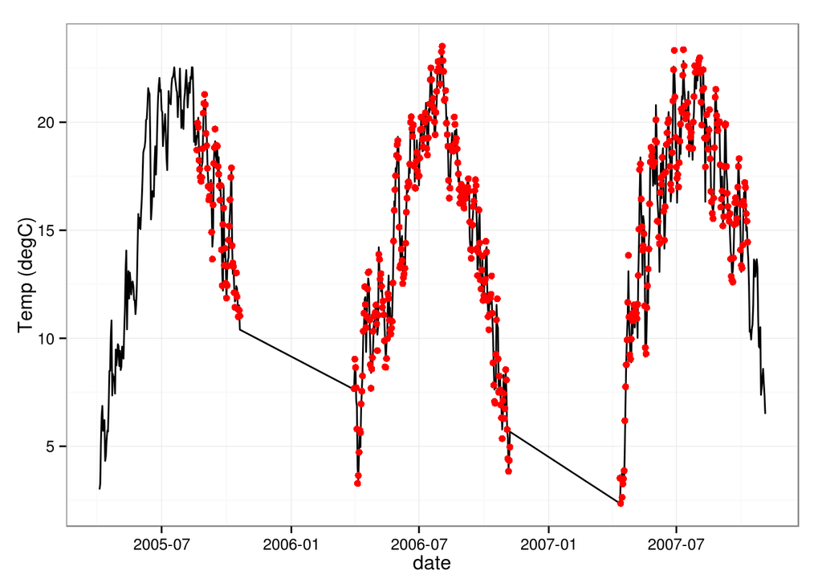

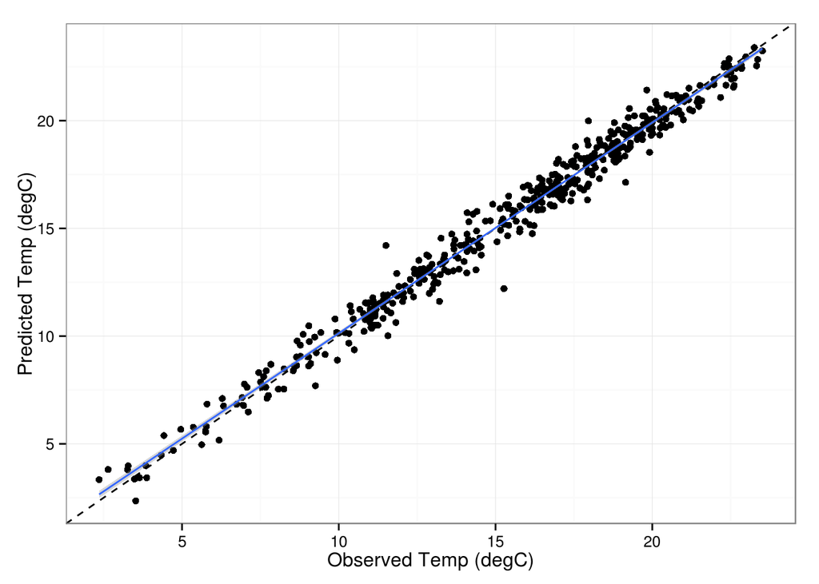

Join the predicted temperature back with un-standardized input data and compute mean predicted temperature.

```
## [1] 14.1403
```

Compute derived metrics.

```
## Observations: 1
## Variables:
## $ featureid       (int) 830189
## $ totalObs        (lgl) TRUE
## $ meanMaxTemp     (dbl) 22.26713
## $ maxMaxTemp      (dbl) 23.77446
## $ meanDays.18     (dbl) 70
## $ meanDays.20     (dbl) 29
## $ meanDays.22     (dbl) 6
## $ yearsMaxTemp.18 (dbl) 34
## $ yearsMaxTemp.20 (dbl) 34
## $ yearsMaxTemp.22 (dbl) 20
## $ meanResist      (dbl) 135.5553
## $ meanRMSE        (dbl) 0.6443841
```

# 3 Prediction Function

The prediction function `predictTemp` takes three arguments:

- `data`: dataframe of the prediction input data (standardized climate and covariate variables)
- `coef.list`: list of fitted coefficients for each covariate
- `cov.list`: list of variables used for each nested model ‘level’

```
## List of 16
##  $ fix.ef    :Classes 'tbl_df', 'tbl' and 'data.frame':  21 obs. of  6 variables:
##   ..$ Parameter: Factor w/ 6979 levels "B.0[1]","B.0[2]",..: 1 2 3 4 5 6 7 8 9 10 ...
##   ..$ mean     : num [1:21] 18.472 -0.366 0.312 -1.099 -0.442 ...
##   ..$ sd       : num [1:21] 0.2071 0.3058 0.355 0.3644 0.0789 ...
##   ..$ qLo      : num [1:21] 18.054 -0.934 -0.417 -1.804 -0.602 ...
##   ..$ qHi      : num [1:21] 18.878 0.269 1.005 -0.404 -0.287 ...
##   ..$ coef     : chr [1:21] "intercept" "Latitude" "Longitude" "TotDASqKM" ...
##  $ rand.ef   :Classes 'tbl_df', 'tbl' and 'data.frame':  17 obs. of  6 variables:
##   ..$ Parameter: Factor w/ 6979 levels "B.0[1]","B.0[2]",..: 6970 6971 6972 6973 6974 6975 6964 6965 6966 6967 ...
##   ..$ mean     : num [1:17] 1.8431 0.4566 0.1775 0.1006 0.0583 ...
##   ..$ sd       : num [1:17] 0.04795 0.01215 0.00629 0.00333 0.00229 ...
##   ..$ qLo      : num [1:17] 1.7512 0.4326 0.1653 0.0945 0.054 ...
##   ..$ qHi      : num [1:17] 1.9423 0.4806 0.1902 0.1075 0.0628 ...
##   ..$ coef     : Factor w/ 6989 levels "airTemp","airTemp.prcp",..: 4 1 3 5 6 2 4 1 3 5 ...
##  $ B.fixed   :Classes 'tbl_df', 'tbl' and 'data.frame':  10 obs. of  6 variables:
##   ..$ Parameter: Factor w/ 6979 levels "B.0[1]","B.0[2]",..: 1 2 3 4 5 6 7 8 9 10
##   ..$ mean     : num [1:10] 18.472 -0.366 0.312 -1.099 -0.442 ...
##   ..$ sd       : num [1:10] 0.2071 0.3058 0.355 0.3644 0.0789 ...
##   ..$ qLo      : num [1:10] 18.054 -0.934 -0.417 -1.804 -0.602 ...
##   ..$ qHi      : num [1:10] 18.878 0.269 1.005 -0.404 -0.287 ...
##   ..$ coef     : chr [1:10] "intercept" "Latitude" "Longitude" "TotDASqKM" ...
##  $ mu.huc    :Classes 'tbl_df', 'tbl' and 'data.frame':  6 obs. of  7 variables:
##   ..$ index    : num [1:6] 1 2 3 4 5 6
##   ..$ Parameter: Factor w/ 6979 levels "B.0[1]","B.0[2]",..: 6900 6901 6902 6903 6904 6905
##   ..$ mean     : num [1:6] 0 2.03077 0.34459 0.00722 0.01432 ...
##   ..$ sd       : num [1:6] 0 0.063 0.0467 0.0362 0.0347 ...
##   ..$ qLo      : num [1:6] 0 1.907 0.2484 -0.0619 -0.0568 ...
##   ..$ qHi      : num [1:6] 0 2.1499 0.438 0.0787 0.0816 ...
##   ..$ coef     : Factor w/ 6 levels "airTemp","airTemp.prcp",..: 4 1 3 5 6 2
##  $ mu.year   :Classes 'tbl_df', 'tbl' and 'data.frame':  4 obs. of  7 variables:
##   ..$ index    : num [1:4] 1 2 3 4
##   ..$ Parameter: Factor w/ 6979 levels "B.0[1]","B.0[2]",..: 6906 6907 6908 6909
##   ..$ mean     : num [1:4] 0 -0.421 -2.137 0.133
##   ..$ sd       : num [1:4] 0 0.1124 0.1288 0.0787
##   ..$ qLo      : num [1:4] 0 -0.6525 -2.3961 -0.0152
##   ..$ qHi      : num [1:4] 0 -0.208 -1.882 0.294
##   ..$ coef     : Factor w/ 4 levels "dOY","dOY2","dOY3",..: 4 1 2 3
##  $ mu.ar1    :Classes 'tbl_df', 'tbl' and 'data.frame':  1 obs. of  6 variables:
##   ..$ Parameter: Factor w/ 6979 levels "B.0[1]","B.0[2]",..: 6899
```

[output cut: 70 more lines]

```
##   ..$ Parameter: Factor w/ 6979 levels "B.0[1]","B.0[2]",..: 6811 6812 6813 6814 6815 6816 6817 6818 6819 6820 ...
##   ..$ mean     : num [1:88] 0.251 0.125 0.374 0.532 0.741 ...
##   ..$ sd       : num [1:88] 0.271 0.276 0.438 0.264 0.177 ...
##   ..$ qLo      : num [1:88] -0.276 -0.4141 -0.4801 0.0187 0.3976 ...
##   ..$ qHi      : num [1:88] 0.799 0.645 1.243 1.051 1.09 ...
##   ..$ year     : Factor w/ 22 levels "1991","1992",..: 1 2 3 4 5 6 7 8 9 10 ...
##   ..$ coef     : Factor w/ 4 levels "dOY","dOY2","dOY3",..: 4 4 4 4 4 4 4 4 4 4 ...
##  $ B.ar1     :Classes 'tbl_df', 'tbl' and 'data.frame':  944 obs. of  7 variables:
##   ..$ index    : num [1:944] 1 2 3 4 5 6 7 8 9 10 ...
##   ..$ Parameter: Factor w/ 6979 levels "B.0[1]","B.0[2]",..: 11 12 13 14 15 16 17 18 19 20 ...
##   ..$ mean     : num [1:944] 0.872 0.886 0.85 0.977 0.781 ...
##   ..$ sd       : num [1:944] 0.0241 0.063 0.066 0.0154 0.1241 ...
##   ..$ qLo      : num [1:944] 0.827 0.749 0.724 0.941 0.504 ...
##   ..$ qHi      : num [1:944] 0.921 0.987 0.974 0.998 0.98 ...
##   ..$ site     : Factor w/ 944 levels "CTDEP_1","CTDEP_1008",..: 1 2 3 4 5 6 7 8 9 10 ...
```

```
## List of 5
##  $ fixed.ef: chr [1:10] "intercept" "Latitude" "Longitude" "TotDASqKM" ...
##  $ site.ef : chr [1:6] "intercept.site" "airTemp" "airTempLagged2" "prcp" ...
##  $ year.ef : chr [1:4] "intercept.year" "dOY" "dOY2" "dOY3"
##  $ huc.ef  : chr [1:6] "intercept.site" "airTemp" "airTempLagged2" "prcp" ...
##  $ ar1.ef  : chr [1:6] "intercept.site" "airTemp" "airTempLagged2" "prcp" ...
```

The `coef.list` object contains multiple data frames with the mean, sd, low/high values of each coefficient. For example, the fixed effects parameters are:

```
## Source: local data frame [10 x 6]
##
##    Parameter       mean         sd        qLo         qHi
## 1     B.0[1] 18.4720231 0.20711765 18.0538047 18.87760438
## 2     B.0[2] -0.3655001 0.30575498 -0.9339998  0.26915798
## 3     B.0[3]  0.3116465 0.35502875 -0.4168086  1.00544633
## 4     B.0[4] -1.0988664 0.36440642 -1.8041232 -0.40444187
## 5     B.0[5] -0.4424734 0.07889847 -0.6018484 -0.28738823
## 6     B.0[6]  0.1212420 0.14877681 -0.1744810  0.40473439
## 7     B.0[7] -0.2334957 0.06283271 -0.3558321 -0.11107207
## 8     B.0[8]  0.4721499 0.08591556  0.2986466  0.63677912
## 9     B.0[9]  1.3261676 0.37490526  0.6074139  2.06048554
## 10   B.0[10] -0.1183657 0.01772925 -0.1531617 -0.08348063
## Variables not shown: coef (chr)
```

Here is the source of the `predictTemp` function, I’ll walk through this step-by-step.

## 3.1 Conditional Coefficients

First prepare the conditional coefficients.

The site coefficients are unique to each site with observed data.

```
##         site intercept.site.B.site airTemp.B.site airTempLagged2.B.site
## 1    CTDEP_1             1.2578088     -0.1263020            0.08484531
## 2 CTDEP_1008            -0.9084381      0.1529970            0.05039532
## 3  CTDEP_101            -0.4746102      0.2543164           -0.15941858
## 4 CTDEP_1030             3.8932751      0.1256987           -0.14887135
## 5 CTDEP_1038            -1.7819292      0.4934692           -0.03867491
## 6 CTDEP_1068            -0.8706286      0.3800239            0.04002566
##   prcp.B.site prcpLagged1.B.site airTemp.prcp.B.site
## 1 -0.03188245       -0.108648733         -0.01731219
## 2  0.03525321        0.070521624          0.04286377
## 3  0.01619213        0.010680232         -0.03284584
## 4 -0.11967470       -0.056528450         -0.03787414
## 5  0.06643119       -0.003515002          0.02056535
## 6 -0.05740766       -0.011369791         -0.02212242
```

The huc coefficients are unique to each huc.

```
##        huc intercept.site.B.huc airTemp.B.huc airTempLagged2.B.huc
## 1 01050001           0.21158768      2.092222            0.3332813
## 2 01050002          -0.01284352      2.151131            0.5113379
## 3 01050004           0.88495896      2.362157            0.6099687
## 4 01070001          -0.08777879      2.052302            0.2688639
## 5 01070003           0.89789031      1.949856            0.2812626
## 6 01070004          -0.04145645      1.989773            0.2675478
##    prcp.B.huc prcpLagged1.B.huc airTemp.prcp.B.huc
## 1 -0.19788329       -0.12627457        -0.02869864
## 2 -0.05692102       -0.01896205        -0.02761145
## 3 -0.15396541       -0.09055544        -0.01155171
## 4  0.13898328        0.04421415        -0.17412735
## 5  0.04254797        0.01746611        -0.14322564
## 6  0.05820669        0.08519798        -0.01110612
```

The year coefficients are unique to each year.

```
##   year intercept.year.B.year dOY.B.year dOY2.B.year dOY3.B.year
## 1 1991             0.2507031 -0.5705137   -2.333859  0.11411258
## 2 1992             0.1246343 -0.6890643   -2.518361  0.57819012
## 3 1993             0.3738921 -0.6395225   -2.826071  0.27454656
## 4 1994             0.5322970 -1.0960559   -3.070439  0.51926832
## 5 1995             0.7412415 -1.3646546   -2.776573  0.58597807
## 6 1996            -0.3906299 -0.1215034   -2.404118  0.06153273
```

The ar1 coefficients are unique to each site with data.

```
## Source: local data frame [6 x 7]
##
##   index Parameter      mean         sd       qLo       qHi       site
## 1     1  B.ar1[1] 0.8722118 0.02411020 0.8269491 0.9210643    CTDEP_1
## 2     2  B.ar1[2] 0.8862273 0.06304729 0.7494881 0.9871344 CTDEP_1008
## 3     3  B.ar1[3] 0.8497359 0.06602661 0.7243748 0.9736101  CTDEP_101
## 4     4  B.ar1[4] 0.9766260 0.01535073 0.9410493 0.9983677 CTDEP_1030
## 5     5  B.ar1[5] 0.7807974 0.12414357 0.5036907 0.9801836 CTDEP_1038
## 6     6  B.ar1[6] 0.6845157 0.06934852 0.5465087 0.8180291 CTDEP_1068
```

## 3.2 Prepare Input Values

We then add the input values for each set of coefficients (site, huc, year, ar1) to the dataframe.

```
##   intercept.site.B.site airTemp.B.site airTempLagged2.B.site prcp.B.site
## 1            -0.5871427     0.06820972            0.01741933 -0.04672892
## 2            -0.5871427     0.06820972            0.01741933 -0.04672892
## 3            -0.5871427     0.06820972            0.01741933 -0.04672892
## 4            -0.5871427     0.06820972            0.01741933 -0.04672892
## 5            -0.5871427     0.06820972            0.01741933 -0.04672892
## 6            -0.5871427     0.06820972            0.01741933 -0.04672892
##   prcpLagged1.B.site airTemp.prcp.B.site
## 1        -0.05062016           0.0246564
## 2        -0.05062016           0.0246564
## 3        -0.05062016           0.0246564
## 4        -0.05062016           0.0246564
## 5        -0.05062016           0.0246564
## 6        -0.05062016           0.0246564
```

```
##   intercept.site.B.huc airTemp.B.huc airTempLagged2.B.huc prcp.B.huc
## 1            0.1734929       2.17277            0.4267125 0.02741676
## 2            0.1734929       2.17277            0.4267125 0.02741676
## 3            0.1734929       2.17277            0.4267125 0.02741676
## 4            0.1734929       2.17277            0.4267125 0.02741676
## 5            0.1734929       2.17277            0.4267125 0.02741676
## 6            0.1734929       2.17277            0.4267125 0.02741676
##   prcpLagged1.B.huc airTemp.prcp.B.huc
## 1        0.03232941        -0.02919445
## 2        0.03232941        -0.02919445
## 3        0.03232941        -0.02919445
## 4        0.03232941        -0.02919445
## 5        0.03232941        -0.02919445
## 6        0.03232941        -0.02919445
```

```
##   intercept.year.B.year dOY.B.year dOY2.B.year dOY3.B.year
## 1          -0.002493817 -0.4230527   -2.136294   0.1334195
## 2          -0.002493817 -0.4230527   -2.136294   0.1334195
## 3          -0.002493817 -0.4230527   -2.136294   0.1334195
## 4          -0.002493817 -0.4230527   -2.136294   0.1334195
## 5          -0.002493817 -0.4230527   -2.136294   0.1334195
## 6          -0.002493817 -0.4230527   -2.136294   0.1334195
```

```
## [1] "B.ar1"
```

```
## [1] 0.8188234 0.8188234 0.8188234 0.8188234 0.8188234 0.8188234
```

## 3.3 Compute Predicted Temperature

To compute the predicted temperatures, we take the linear sum of each set of factors using matrix multiplication. The plot below shows the predicted temperature time series over all years.

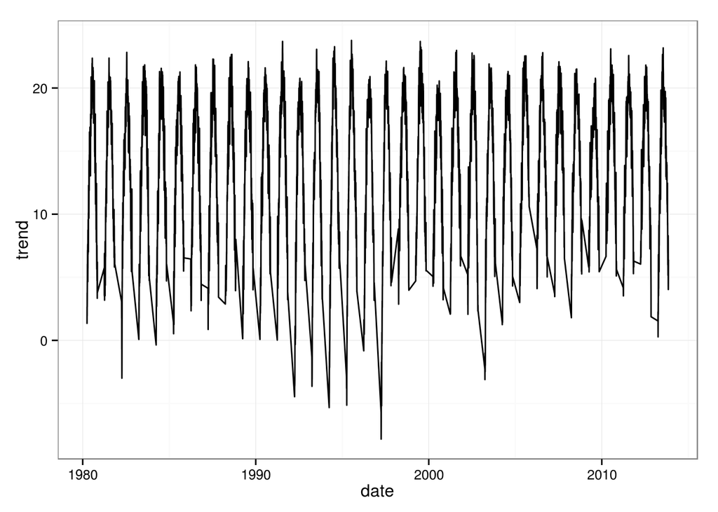

The final predicted temperature is adjusted using the autoregressive residual term (`B.ar1`). The plot below shows the change in predicted temperature due to the autoregressive residuals which ranges from -2 to +2 degC.

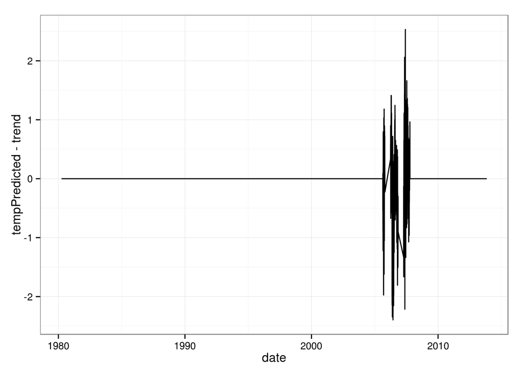

## 3.4 prepConditionalCoef() Function

```
##         site intercept.site.B.site airTemp.B.site airTempLagged2.B.site
## 1    CTDEP_1             1.2578088     -0.1263020            0.08484531
## 2 CTDEP_1008            -0.9084381      0.1529970            0.05039532
## 3  CTDEP_101            -0.4746102      0.2543164           -0.15941858
## 4 CTDEP_1030             3.8932751      0.1256987           -0.14887135
## 5 CTDEP_1038            -1.7819292      0.4934692           -0.03867491
## 6 CTDEP_1068            -0.8706286      0.3800239            0.04002566
##   prcp.B.site prcpLagged1.B.site airTemp.prcp.B.site
## 1 -0.03188245       -0.108648733         -0.01731219
## 2  0.03525321        0.070521624          0.04286377
## 3  0.01619213        0.010680232         -0.03284584
## 4 -0.11967470       -0.056528450         -0.03787414
## 5  0.06643119       -0.003515002          0.02056535
## 6 -0.05740766       -0.011369791         -0.02212242
```

```
## Source: local data frame [6 x 9]
##
##   index2 index   Parameter       mean        sd        qLo         qHi
## 1      1     1 B.site[1,1]  1.2578088 0.3801636  0.5378338  2.00670015
## 2      1     2 B.site[2,1] -0.9084381 0.5284053 -2.0607052  0.02701856
## 3      1     3 B.site[3,1] -0.4746102 0.5164547 -1.4351361  0.62642156
## 4      1     4 B.site[4,1]  3.8932751 0.7172009  2.4181247  5.26401947
## 5      1     5 B.site[5,1] -1.7819292 0.4758603 -2.7184497 -0.78930650
## 6      1     6 B.site[6,1] -0.8706286 0.2469199 -1.3521983 -0.37851881
## Variables not shown: site (fctr), coef (fctr)
```

```
##         site    airTemp airTemp.prcp airTempLagged2 intercept.site
## 1    CTDEP_1 -0.1263020  -0.01731219     0.08484531      1.2578088
## 2 CTDEP_1008  0.1529970   0.04286377     0.05039532     -0.9084381
## 3  CTDEP_101  0.2543164  -0.03284584    -0.15941858     -0.4746102
## 4 CTDEP_1030  0.1256987  -0.03787414    -0.14887135      3.8932751
## 5 CTDEP_1038  0.4934692   0.02056535    -0.03867491     -1.7819292
## 6 CTDEP_1068  0.3800239  -0.02212242     0.04002566     -0.8706286
##          prcp  prcpLagged1
## 1 -0.03188245 -0.108648733
## 2  0.03525321  0.070521624
## 3  0.01619213  0.010680232
## 4 -0.11967470 -0.056528450
## 5  0.06643119 -0.003515002
## 6 -0.05740766 -0.011369791
```

```
## [1] "site"                  "intercept.site.B.site" "airTemp.B.site"
## [4] "airTempLagged2.B.site" "prcp.B.site"           "prcpLagged1.B.site"
## [7] "airTemp.prcp.B.site"
```

Add the site covariates to the data frame

```
##   intercept.site.B.site airTemp.B.site airTempLagged2.B.site prcp.B.site
## 1            -0.5871427     0.06820972            0.01741933 -0.04672892
## 2            -0.5871427     0.06820972            0.01741933 -0.04672892
## 3            -0.5871427     0.06820972            0.01741933 -0.04672892
## 4            -0.5871427     0.06820972            0.01741933 -0.04672892
## 5            -0.5871427     0.06820972            0.01741933 -0.04672892
## 6            -0.5871427     0.06820972            0.01741933 -0.04672892
##   prcpLagged1.B.site airTemp.prcp.B.site
## 1        -0.05062016           0.0246564
## 2        -0.05062016           0.0246564
## 3        -0.05062016           0.0246564
## 4        -0.05062016           0.0246564
## 5        -0.05062016           0.0246564
## 6        -0.05062016           0.0246564
```

Create two matrices with columns for covariates and coefficients

```
## [1] "intercept.site" "airTemp"        "airTempLagged2" "prcp"
## [5] "prcpLagged1"    "airTemp.prcp"
```

```
## [1] "intercept.site.B.site" "airTemp.B.site"        "airTempLagged2.B.site"
## [4] "prcp.B.site"           "prcpLagged1.B.site"    "airTemp.prcp.B.site"
```

```
##      intercept.site   airTemp airTempLagged2       prcp prcpLagged1
## [1,]              1 -2.157086             NA  0.5985377          NA
## [2,]              1 -2.665931             NA -0.4594738   0.5978843
## [3,]              1 -2.665931      -2.168564 -0.4594738  -0.4598302
## [4,]              1 -2.046468      -2.678835 -0.4594738  -0.4598302
## [5,]              1 -2.444694      -2.678835 -0.1420704  -0.4598302
## [6,]              1 -1.847355      -2.057635 -0.4594738  -0.1425159
##      airTemp.prcp
## [1,]   -1.2910975
## [2,]    1.2249253
## [3,]    1.2249253
## [4,]    0.9402984
## [5,]    0.3473186
## [6,]    0.8488112
```

```
## [1] 7511    6
```

```
##      intercept.site.B.site airTemp.B.site airTempLagged2.B.site
## [1,]            -0.5871427     0.06820972            0.01741933
## [2,]            -0.5871427     0.06820972            0.01741933
## [3,]            -0.5871427     0.06820972            0.01741933
## [4,]            -0.5871427     0.06820972            0.01741933
## [5,]            -0.5871427     0.06820972            0.01741933
## [6,]            -0.5871427     0.06820972            0.01741933
##      prcp.B.site prcpLagged1.B.site airTemp.prcp.B.site
## [1,] -0.04672892        -0.05062016           0.0246564
## [2,] -0.04672892        -0.05062016           0.0246564
## [3,] -0.04672892        -0.05062016           0.0246564
## [4,] -0.04672892        -0.05062016           0.0246564
## [5,] -0.04672892        -0.05062016           0.0246564
## [6,] -0.04672892        -0.05062016           0.0246564
```

```
## [1] 7511    6
```

Multiple two matrices and sum the rows

```
## [1] 7511
```

```
## [1]         NA         NA -0.7318103 -0.7054634 -0.7620790 -0.6993793
```

# 4 Model Details

## 4.1 Model Theory

This equation defines the predicted temperature without the autoregressive residual term.

$\omega_{s,h,d,y} = X^0 B^0 + X_h^{huc} B_h^{huc} + X_{s,h}^{site} B_{s,h}^{site} + X_y^{year} B_y^{year}$

where $\omega_{s,h,d,y}$ is the expected temperature without residual error terms of site $s$, within HUC $h$, on julian day $d$ within year $y$. This value is a linear combination of four terms:

- $X^0 B^0$: fixed effects including the intercept
- $X_h^{huc} B_h^{huc}$: effects for HUC $h$
- $X_{s, h}^{site} B_{s, h}^{site}$: effects for site $s$
- $X_y^{year} B_y^{year}$: effects for year $y$

Each of these terms produces a vector of length $n_{d}$.

## 4.2 Sets of Coefficients

### 4.2.1 Fixed Effects

The fixed effect variables include:

```
## Source: local data frame [10 x 3]
##
##                   coef       mean         sd
## 1            intercept 18.4720231 0.20711765
## 2             Latitude -0.3655001 0.30575498
## 3            Longitude  0.3116465 0.35502875
## 4            TotDASqKM -1.0988664 0.36440642
## 5               Forest -0.4424734 0.07889847
## 6      ReachElevationM  0.1212420 0.14877681
## 7     SurficialCoarseC -0.2334957 0.06283271
## 8         CONUSWetland  0.4721499 0.08591556
## 9  ImpoundmentsAllSqKM  1.3261676 0.37490526
## 10   airTemp.TotDASqKM -0.1183657 0.01772925
```

This plot shows the mean +/- 1 stdev for each effect excluding the intercept.

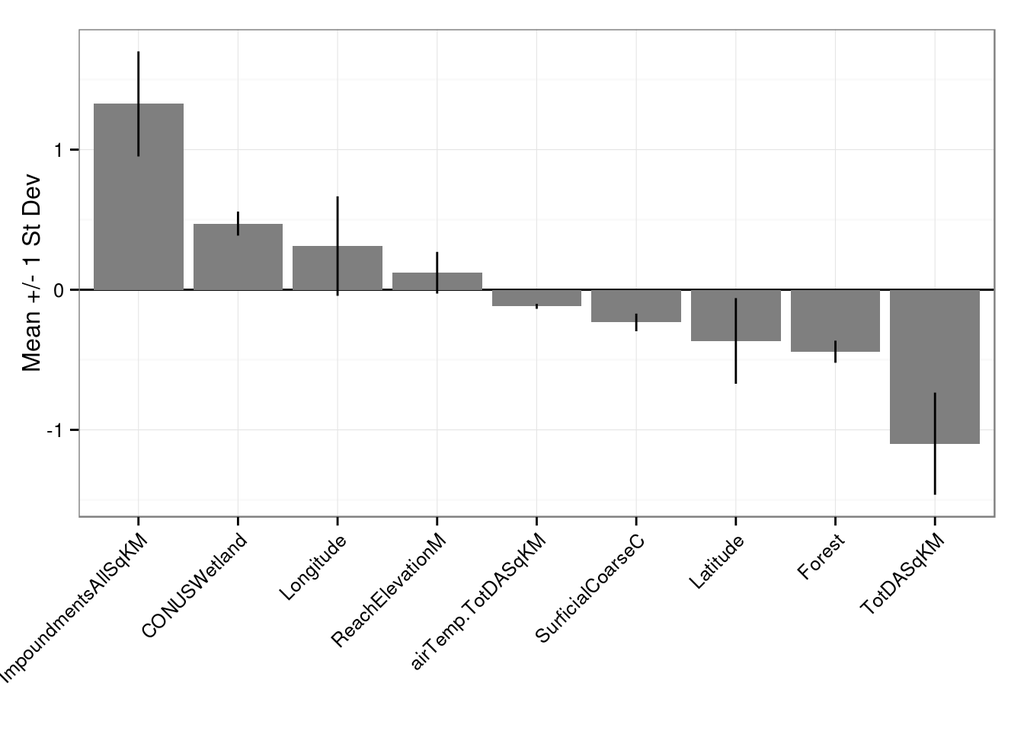

Only one of these variables (`airTemp.TotDASqKM`) varies by day, the rest are constant for each site/catchment.

```
##   intercept    Latitude   Longitude  TotDASqKM    Forest ReachElevationM
## 1         1 -0.03513392 -0.08475244 -0.1598095 0.1746388       0.6518523
## 2         1 -0.03513392 -0.08475244 -0.1598095 0.1746388       0.6518523
## 3         1 -0.03513392 -0.08475244 -0.1598095 0.1746388       0.6518523
## 4         1 -0.03513392 -0.08475244 -0.1598095 0.1746388       0.6518523
## 5         1 -0.03513392 -0.08475244 -0.1598095 0.1746388       0.6518523
## 6         1 -0.03513392 -0.08475244 -0.1598095 0.1746388       0.6518523
##   SurficialCoarseC CONUSWetland ImpoundmentsAllSqKM airTemp.TotDASqKM
## 1       -0.9230302    0.2173934          -0.1182131         0.3447229
## 2       -0.9230302    0.2173934          -0.1182131         0.4260411
## 3       -0.9230302    0.2173934          -0.1182131         0.4260411
## 4       -0.9230302    0.2173934          -0.1182131         0.3270451
## 5       -0.9230302    0.2173934          -0.1182131         0.3906854
## 6       -0.9230302    0.2173934          -0.1182131         0.2952249
```

Using matrix multiplication to compute the row-wise sum of the fixed effects.

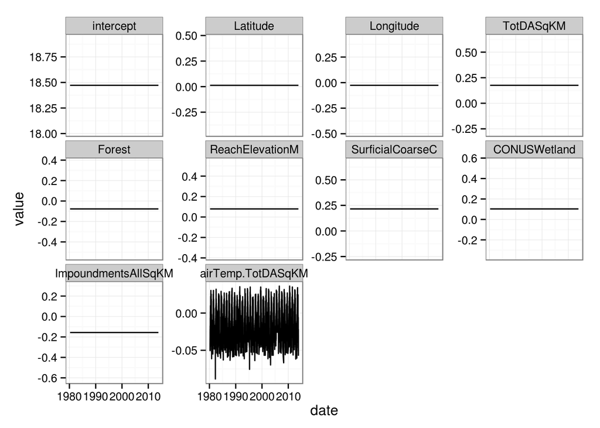

### 4.2.2 HUC Effects

The huc effects include:

```
## Source: local data frame [32 x 7]
##
##         huc  airTemp airTemp.prcp airTempLagged2 intercept.site
## 1  01050001 2.092222  -0.02869864      0.3332813     0.21158768
## 2  01050002 2.151131  -0.02761145      0.5113379    -0.01284352
## 3  01050004 2.362157  -0.01155171      0.6099687     0.88495896
## 4  01070001 2.052302  -0.17412735      0.2688639    -0.08777879
## 5  01070003 1.949856  -0.14322564      0.2812626     0.89789031
## 6  01070004 1.989773  -0.01110612      0.2675478    -0.04145645
## 7  01070005 2.511778   0.17565874      0.2483573     0.27816628
## 8  01070006 2.445114  -0.13298623      0.3975328     0.37746070
## 9  01080101 1.817906  -0.19321300      0.2161348    -1.23386557
## 10 01080102 1.792537  -0.21922670      0.2784511    -0.17613027
## ..      ...      ...          ...            ...            ...
## Variables not shown: prcp (dbl), prcpLagged1 (dbl)
```

For the selected catchment, which is in HUC 01080204, the parameters are:

```
## Source: local data frame [6 x 4]
##
##        huc           coef        mean         sd
## 1 01080204 intercept.site  0.17349293 0.39150153
## 2 01080204        airTemp  2.17276986 0.11441445
## 3 01080204 airTempLagged2  0.42671247 0.06129833
## 4 01080204           prcp  0.02741676 0.03203091
## 5 01080204    prcpLagged1  0.03232941 0.01830023
## 6 01080204   airTemp.prcp -0.02919445 0.02962109
```

This plot shows the mean +/- 1 stdev for each effect within HUC 01080204.

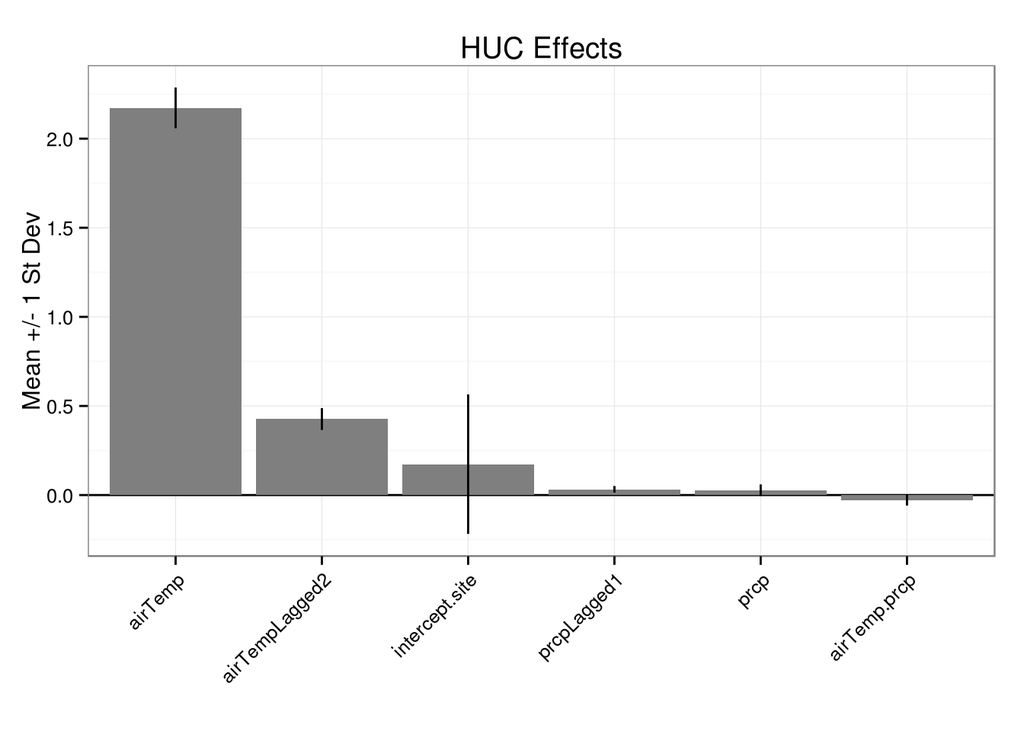

All of these variables varies by day, except for the site intercept, which is always 1.

```
##   intercept.site   airTemp airTempLagged2       prcp prcpLagged1
## 1              1 -2.157086             NA  0.5985377          NA
## 2              1 -2.665931             NA -0.4594738   0.5978843
## 3              1 -2.665931      -2.168564 -0.4594738  -0.4598302
## 4              1 -2.046468      -2.678835 -0.4594738  -0.4598302
## 5              1 -2.444694      -2.678835 -0.1420704  -0.4598302
## 6              1 -1.847355      -2.057635 -0.4594738  -0.1425159
##   airTemp.prcp
## 1   -1.2910975
## 2    1.2249253
## 3    1.2249253
## 4    0.9402984
## 5    0.3473186
## 6    0.8488112
```

Using matrix multiplication to compute the row-wise sum of the fixed effects.

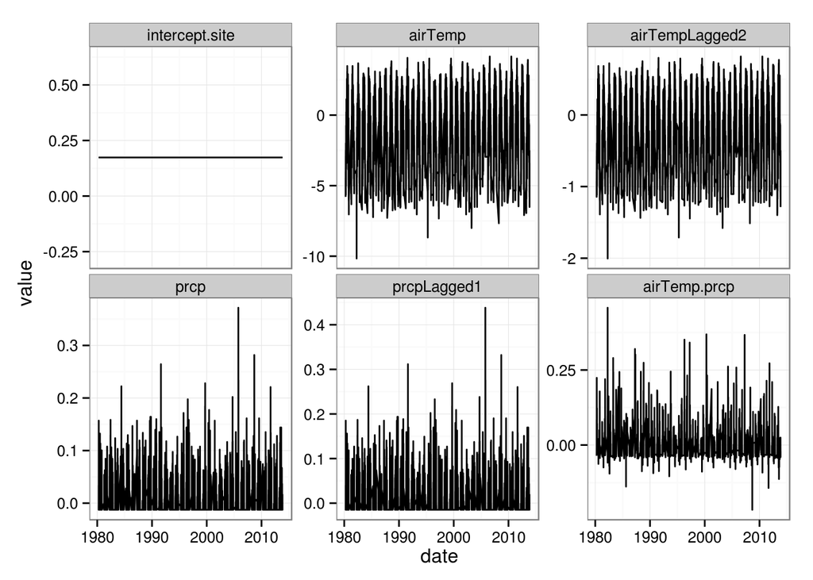

### 4.2.3 Site Effects

The site effects include:

```
## Source: local data frame [944 x 7]
##
##          site     airTemp airTemp.prcp airTempLagged2 intercept.site
## 1     CTDEP_1 -0.12630205 -0.017312187     0.08484531      1.2578088
## 2  CTDEP_1008  0.15299703  0.042863774     0.05039532     -0.9084381
## 3   CTDEP_101  0.25431639 -0.032845844    -0.15941858     -0.4746102
## 4  CTDEP_1030  0.12569869 -0.037874140    -0.14887135      3.8932751
## 5  CTDEP_1038  0.49346919  0.020565352    -0.03867491     -1.7819292
## 6  CTDEP_1068  0.38002386 -0.022122422     0.04002566     -0.8706286
## 7  CTDEP_1081  0.14522074 -0.001672359     0.13879345      1.2955307
## 8  CTDEP_1083  0.03244799  0.027782866     0.04201264      0.1108283
## 9  CTDEP_1084  0.13868452  0.004551128     0.02550003     -3.2756975
## 10 CTDEP_1088  0.20342990  0.002046396     0.11325701     -0.7732254
## ..        ...         ...          ...            ...            ...
## Variables not shown: prcp (dbl), prcpLagged1 (dbl)
```

For the selected site, which is MAFW_MAPleas55, the parameters are:

```
## Source: local data frame [6 x 4]
##
##             site           coef        mean         sd
## 1 MAFW_MAPleas55 intercept.site -0.58714267 0.43383025
## 2 MAFW_MAPleas55        airTemp  0.06820972 0.12927053
## 3 MAFW_MAPleas55 airTempLagged2  0.01741933 0.08083308
## 4 MAFW_MAPleas55           prcp -0.04672892 0.04125514
## 5 MAFW_MAPleas55    prcpLagged1 -0.05062016 0.02782671
## 6 MAFW_MAPleas55   airTemp.prcp  0.02465640 0.03642801
```

This plot shows the mean +/- 1 stdev for each effect for site MAFW_MAPleas55.

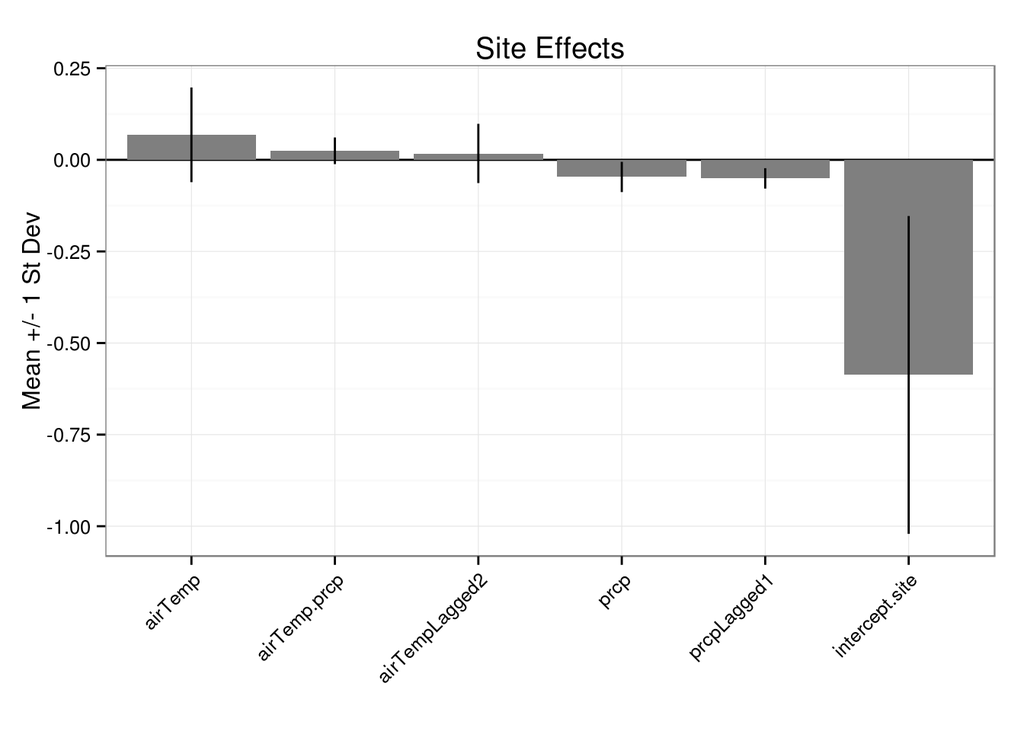

All of these variables varies by day, except for the site intercept, which is always 1.

```
##   intercept.site   airTemp airTempLagged2       prcp prcpLagged1
## 1              1 -2.157086             NA  0.5985377          NA
## 2              1 -2.665931             NA -0.4594738   0.5978843
## 3              1 -2.665931      -2.168564 -0.4594738  -0.4598302
## 4              1 -2.046468      -2.678835 -0.4594738  -0.4598302
## 5              1 -2.444694      -2.678835 -0.1420704  -0.4598302
## 6              1 -1.847355      -2.057635 -0.4594738  -0.1425159
##   airTemp.prcp
## 1   -1.2910975
## 2    1.2249253
## 3    1.2249253
## 4    0.9402984
## 5    0.3473186
## 6    0.8488112
```

Using matrix multiplication to compute the row-wise sum of the fixed effects.

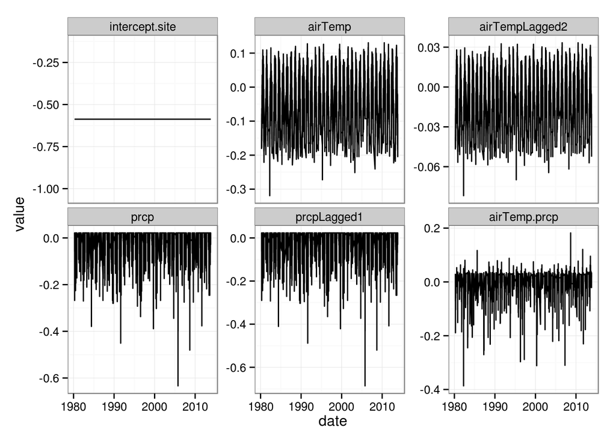

### 4.2.4 Year Effects

The year effects include:

```
## Source: local data frame [22 x 5]
##
##    year        dOY      dOY2        dOY3 intercept.year
## 1  1991 -0.5705137 -2.333859  0.11411258      0.2507031
## 2  1992 -0.6890643 -2.518361  0.57819012      0.1246343
## 3  1993 -0.6395225 -2.826071  0.27454656      0.3738921
## 4  1994 -1.0960559 -3.070439  0.51926832      0.5322970
## 5  1995 -1.3646546 -2.776573  0.58597807      0.7412415
## 6  1996 -0.1215034 -2.404118  0.06153273     -0.3906299
## 7  1997 -0.8659866 -3.201794  0.61576778      0.4666966
## 8  1998  0.1369618 -1.893005 -0.07001396     -0.2070093
## 9  1999 -0.7643593 -2.106699  0.06774042      0.6747621
## 10 2000 -0.1498699 -2.152647 -0.19433576     -0.2641565
## ..  ...        ...       ...         ...            ...
```

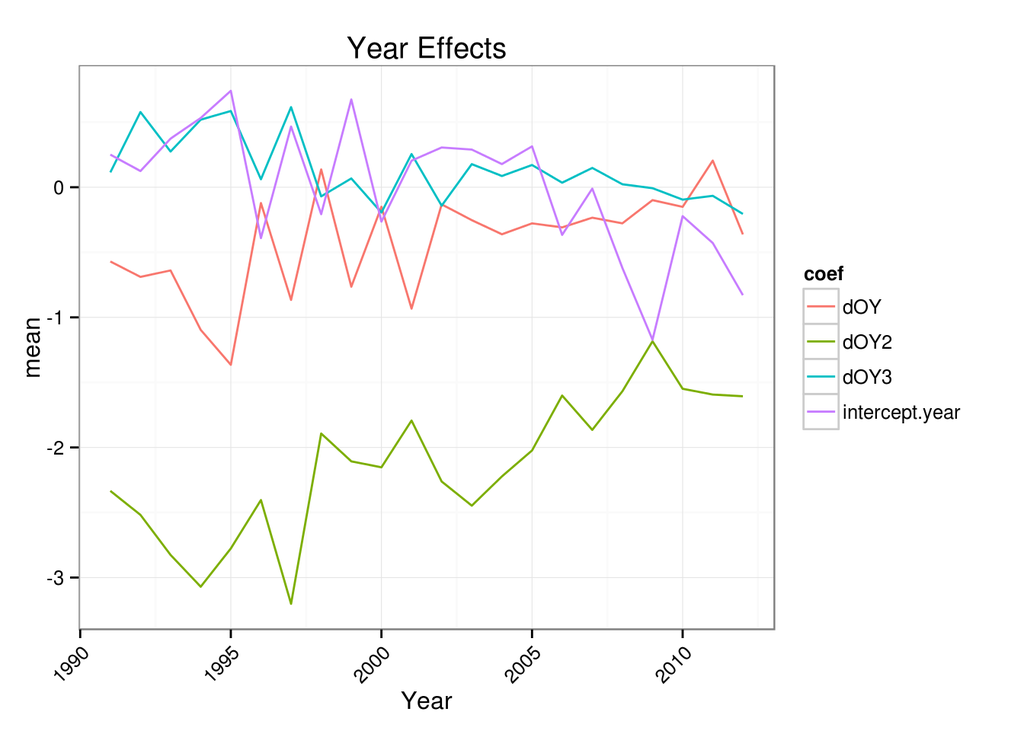

All of these variables varies by day, except for the intercept, which is always 1.

```
##   intercept.year       dOY     dOY2       dOY3
## 1              1 -2.168378 4.701863 -10.195415
## 2              1 -2.150267 4.623650  -9.942082
## 3              1 -2.132157 4.546092  -9.692981
## 4              1 -2.114046 4.469191  -9.448076
## 5              1 -2.095936 4.392946  -9.207332
## 6              1 -2.077825 4.317357  -8.970712
```

Using matrix multiplication to compute the row-wise sum of the fixed effects.

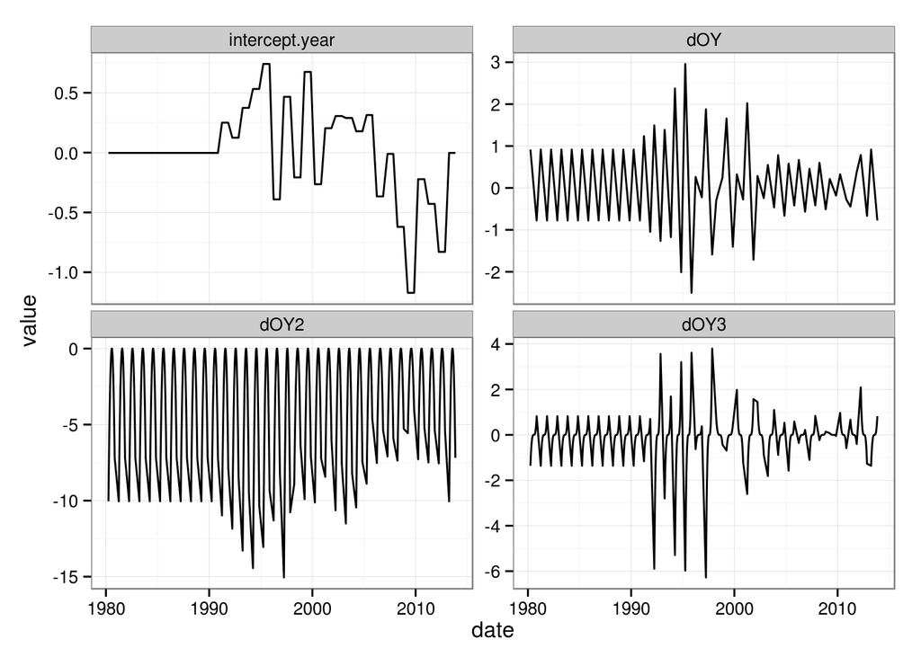

Curious to see how variable the cubic spline is for each year.

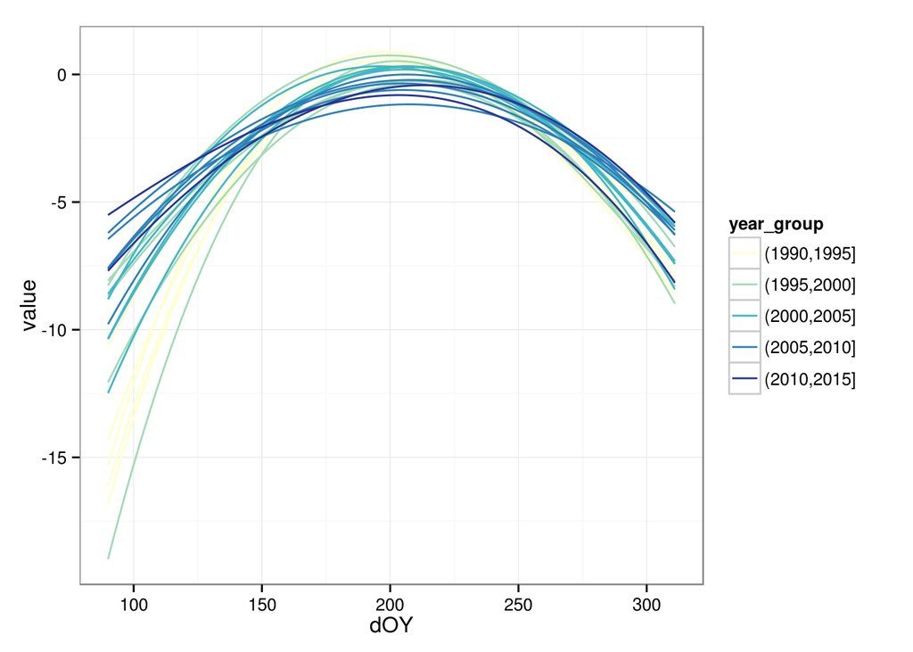

## 4.3 Sum All Effects

This figure shows the contributions from each set of factors. The black line is the overall sum representing the predicted temperature for this site (excluding the autoregressive error term).

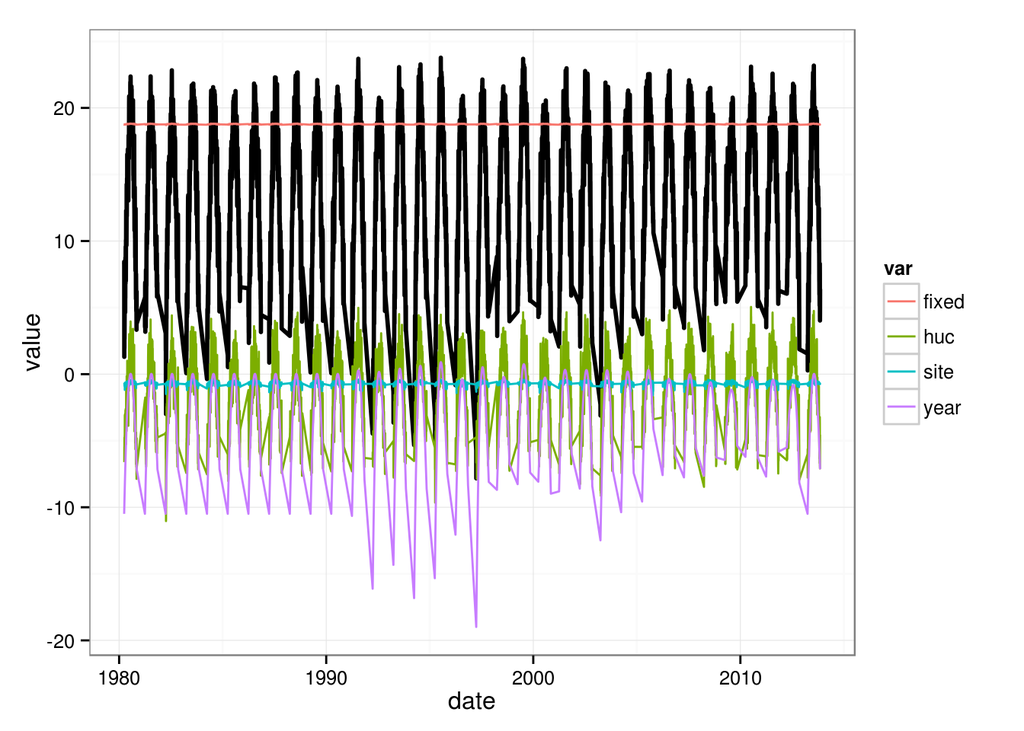

# 5 Example Predictions for 2006

THis section focuses on the predictions for one site (MAFW_MAPleas55), which is in catchment (830189) and HUC8 (01080204), and one year (2006). This figure shows the contributions from each set of factors. The black lines are the sum of all lines within each panel.

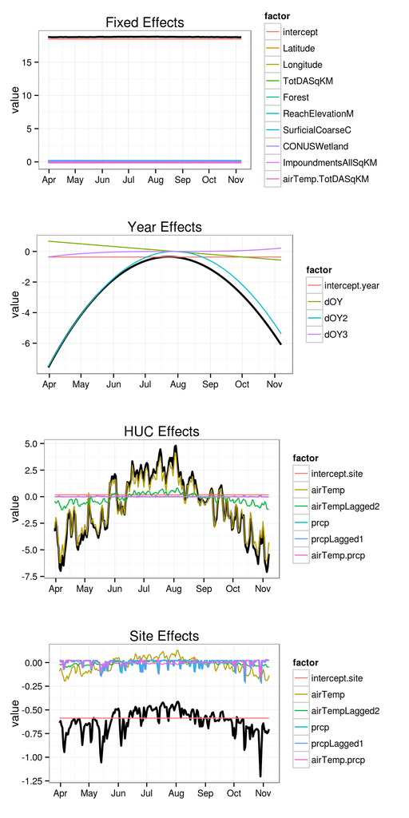

This figure takes the sum of each set of factors (black line in each panel above) and computes the overall predicted temperature (shown in this figure as the black line). This does not include the autoregressive residual term.

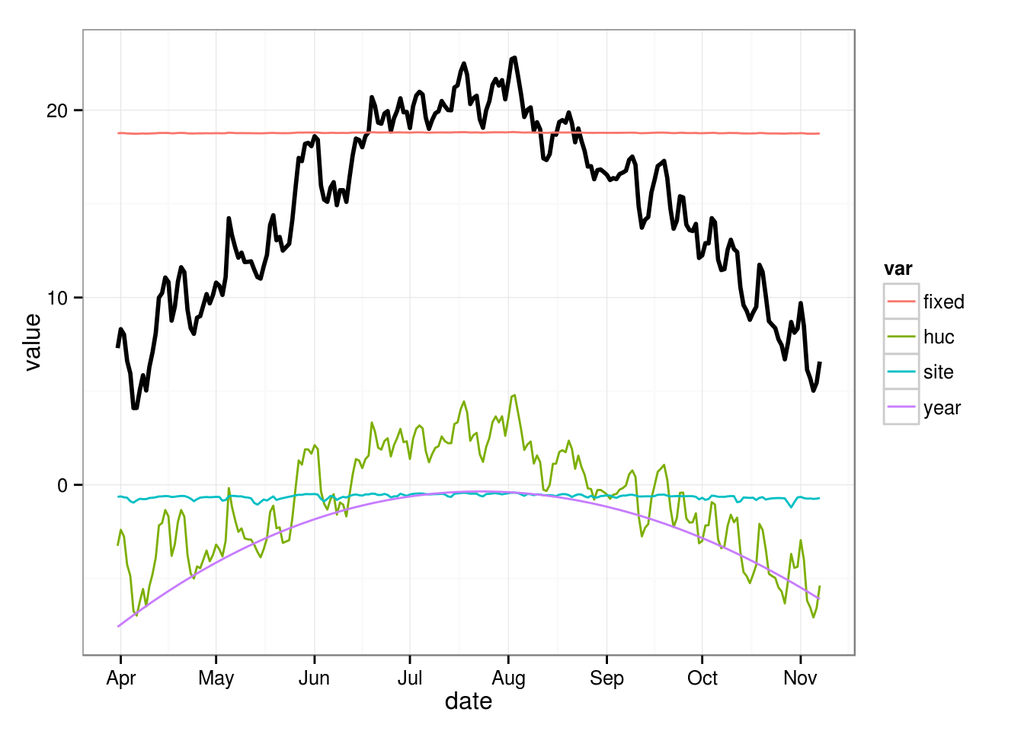